# Predicted Calculation Times Pilot

# What does this file do?

We want a way of estimating the calculation times for larger simulation numbers, without having to run them. In this case, it is reasonable to assume that increasing the simulation number linearly also increases computation time linearly, since in terms of computation time, running the file with n simulations is very similar to running the file with 1 simulation, n times.

We fit a linear model without an intercept (since 0 simulations should take no time) and use this to extrapolate for larger values. We then decide which simulation number would be reasonable for our main analysis. The way that this pilot code behaves allows for running this file again to obtain new estimates very easily if the driver code is changed.

## First code block:

This block obtains our response (computation time) for our chosen values of pilot simulation numbers per case

```r
#### NEEDS TO BE RUN ON A CLEAN ENVIRONMENT AND ENVIRONMENT SHOULD BE CLEANED
#### BEFORE RUNNING FULL SIMULATION

### Note: running this code on any other machines will not produce the same
### predicted times, refer to the figure in the report for the specific
### graph this produced on my machine.

x <- seq(2)  # Setting this to 5 takes 2 minutes on my machine, but 3 is enough
y <- rep(NA, length(x))

for (j in x){
  # Our x values are the number of different simulations we run for each case.
  # Our y values is the computation time required for the respective x.
  # We will attempt to draw a graph of simulations per case and computation
  # time, so that we can select a compromise between high simulations and
  # available time.

  pilot.sims <- x[j]
  y.val <- system.time(source('driver.R'))[3]
  y[j] <- y.val
}
```

## Second code block:

This block fits the linear model and gives us a summary

```r
A = lm(y~x-1)    # We fit a lm and check it
summary(A)       # produces a reasonable answer.
```

```
##
## Call:
## lm(formula = y ~ x - 1)
##
## Residuals:
##      1      2
##  0.688 -0.344
##
## Coefficients:
##   Estimate Std. Error t value Pr(>|t|)
## x   10.362      0.344   30.12   0.0211 *
## ---
## Signif. codes:  0 '***' 0.001 '**' 0.01 '*' 0.05 '.' 0.1 ' ' 1
##
## Residual standard error: 0.7692 on 1 degrees of freedom
## Multiple R-squared:  0.9989, Adjusted R-squared:  0.9978
## F-statistic: 907.3 on 1 and 1 DF,  p-value: 0.02113
```

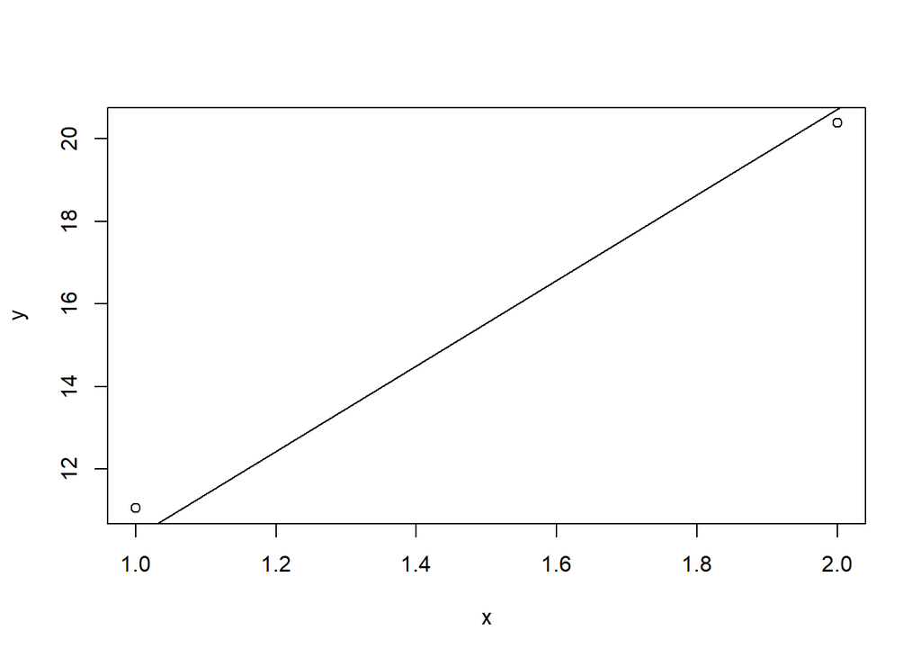

```r
plot(x,y)                    # We visualise the fitted line
abline(0,A$coefficients)
```

## Third code block:

This block plots the fitted model so we can use the visual aid to decide how many simulations we want to use in the final study

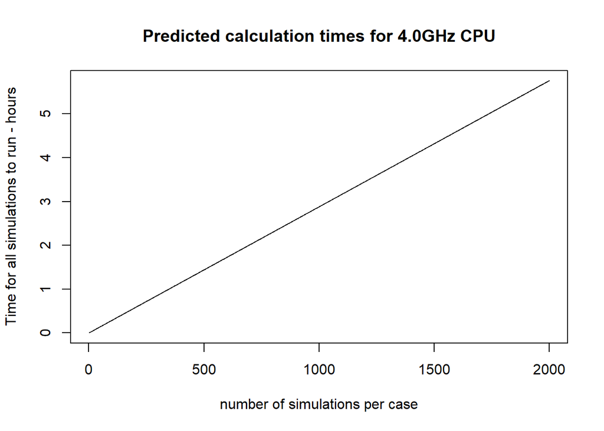

```r
pred.time <- function(s){     # We write a very simple function
  secs <- A$coefficients*s    # which returns the expected
  mins <- secs/60             # calculation time for s simulations
  hours <- mins/60            # per case, based on our observed
  return(hours)               # values
}

plot.x = seq(1,2000)        # we plot expected calculation times
plot.y = pred.time(plot.x)  # so that we can choose how many to use

plot(plot.x, plot.y, xlab = 'number of simulations per case',
     ylab = 'Time for all simulations to run - hours',
     type='l',
     main = 'Predicted calculation times for 4.0GHz CPU')
```

## Final decision:

Jusding by the graph this produced on my machine, I select 1000 as the chosen simulation number for the analysis, which has a predicted computation time (in hours) of:

```
##        x
## 2.878333
```